# (Null) Hypothesis Testing

Lecture 22

March 16, 2026

# Review

## Model Assessment

- Metrics are based on **loss functions** which penalize differences between projections and observations.
- Scoring rules are the extension to probabilistic forecasts.
- Cross-validation for separating training and testing data.
- Information criteria as “full data” approximation to cross-validation.
- **Never read into in-sample error metrics.**

# Statistics and Decision-Making

## Science as Decision-Making Under Uncertainty

Goal is to draw insights:

- About causes and effects;
- About interventions.

[figure not shown]

XKCD 2440

Source: [XKCD 2440](https://xkcd.com/2440)

## Questions We Might Like To Answer

- Are high water levels influenced by environmental change?
- Does some environmental condition have an effect on water quality/etc?
- Does a drug or treatment have some effect?

Each of these is a **hypothesis** about causation or influence.

# Null Hypothesis Testing

## Onus probandi incumbit ei qui dicit, non ei qui negat

**Core assumption**: Burden of proof is on someone claiming an effect (or a similar hypothesis).

[figure not shown]

Null Hypothesis Meme

## Null Hypothesis Significance Testing

- Check if the data is consistent with a “null” model;
- If the data is unlikely from the null model (to some level of **significance**), this is evidence for the alternative.
- If the data is consistent with the null, there is no need for an alternative hypothesis.

[figure not shown]

Alternative Hypothesis Meme

## From Null Hypothesis to Null Model

> …**the null hypothesis must be exact**, that is free of vagueness and ambiguity, **because it must supply the basis of the ‘problem of distribution,’** of which the test of significance is the solution.

— R. A. Fisher, *The Design of Experiments*, 1935.

## Example: High Water Nonstationarity

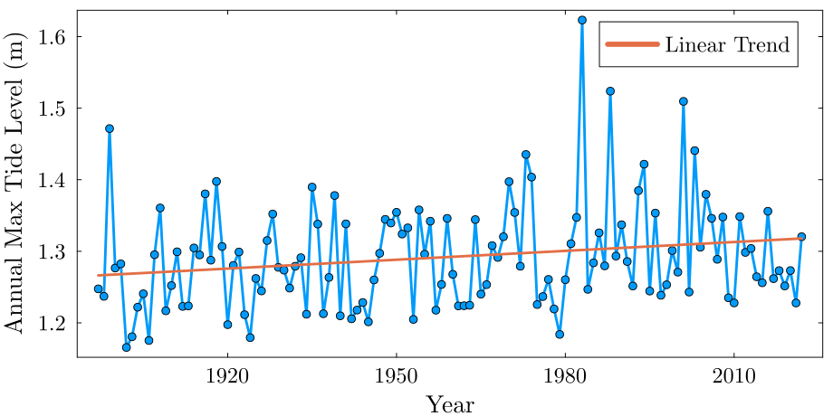

Figure 1: Annual maxima surge data from the San Francisco, CA tide gauge.

```julia
# load SF tide gauge data
# read in data and get annual maxima
function load_data(fname)
    date_format = DateFormat("yyyy-mm-dd HH:MM:SS")
    # This uses the DataFramesMeta.jl package, which makes it easy to string together commands to load and process data
    df = @chain fname begin
        CSV.read(DataFrame; header=false)
        rename("Column1" => "year", "Column2" => "month", "Column3" => "day", "Column4" => "hour", "Column5" => "gauge")
        # need to reformat the decimal date in the data file
        @transform :datetime = DateTime.(:year, :month, :day, :hour)
        # replace -99999 with missing
        @transform :gauge = ifelse.(abs.(:gauge) .>= 9999, missing, :gauge)
        select(:datetime, :gauge)
    end
    return df
end

dat = load_data("data/surge/h551.csv")

# detrend the data to remove the effects of sea-level rise and seasonal dynamics
ma_length = 366
ma_offset = Int(floor(ma_length/2))
moving_average(series,n) = [mean(@view series[i-n:i+n]) for i in n+1:length(series)-n]
dat_ma = DataFrame(datetime=dat.datetime[ma_offset+1:end-ma_offset], residual=dat.gauge[ma_offset+1:end-ma_offset] .- moving_average(dat.gauge, ma_offset))

# group data by year and compute the annual maxima
dat_ma = dropmissing(dat_ma) # drop missing data
dat_annmax = combine(dat_ma -> dat_ma[argmax(dat_ma.residual), :], groupby(transform(dat_ma, :datetime => x->year.(x)), :datetime_function))
delete!(dat_annmax, nrow(dat_annmax)) # delete 2023; haven't seen much of that year yet
rename!(dat_annmax, :datetime_function => :Year)
select!(dat_annmax, [:Year, :residual])
dat_annmax.residual = dat_annmax.residual / 1000 # convert to m

# make plots
p1 = plot(
    dat_annmax.Year,
    dat_annmax.residual;
    xlabel="Year",
    ylabel="Annual Max Tide Level (m)",
    label=false,
    marker=:circle,
    markersize=5,
    tickfontsize=16,
    guidefontsize=18,
    left_margin=5mm,
    bottom_margin=5mm
)

n = nrow(dat_annmax)
linfit = lm(@formula(residual ~ Year), dat_annmax)
pred = coef(linfit)[1] .+ coef(linfit)[2] * dat_annmax.Year

plot!(p1, dat_annmax.Year, pred, linewidth=3, label="Linear Trend")
```

## The Null: Is The Trend Real?

$\mathcal{H}_0$ (Null Hypothesis):

- The “trend” is just due to chance, there is no “true” long-term trend in the data.
- Statistically:

$$y = \underbrace{b}_{\text{constant}} + \underbrace{\varepsilon}_{\text{residuals}}, \qquad \varepsilon \underbrace{\sim}_{\substack{\text{distributed} \\ {\text{according to}}}} \mathcal{N}(0, \sigma^2)$$

## An Alternative Hypothesis

$\mathcal{H}$:

- The trend is *likely* non-zero in time.
- Statistically:

$$y = \alpha + \beta \times t + \varepsilon, \qquad \varepsilon \sim Normal(0, \sigma^2)$$

## Null Test

Comparing $\mathcal{H}$ with $\mathcal{H}_0$:

- $\mathcal{H}$: $\beta \neq 0$
- $\mathcal{H}_0$: $\beta = 0$

## Computing the Test Statistic

For this type of null hypothesis test, our **test statistic** is the slope of the linear fit. OLS estimate:
$$\hat{\beta} = \frac{\sum_{i=1}^n (x_i - \bar{x})(y_i - \bar{y})}{(x_i - \bar{x})^2}.$$

Idea is that even **assuming the null hypothesis**, we could obtain many different datasets, **some of which will have a non-zero slope by chance**.

## Sampling Distribution of Test Statistic

**Standard Result**:
$$\frac{\hat{\beta} - \beta}{\text{se}\left[\hat{\beta}\right]} \sim t_{n-2},$$

where $t_{n-2}$ is the **t-distribution** with $n-2$ degrees of freedom.

This is why the standard “test” for linear regression coefficients is called a **t-test**.

## Statistical Significance

Is the value of the test statistic consistent with the null hypothesis?

More formally, could the test statistic have been reasonably observed from a random sample **given the null hypothesis**?

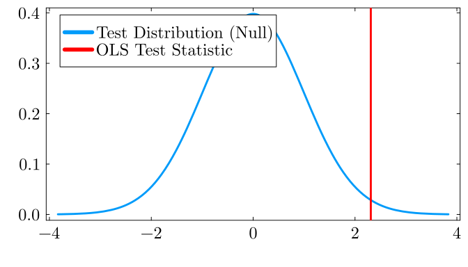

## p-Values: Quantification of “Surprise”

One-Tailed Test:

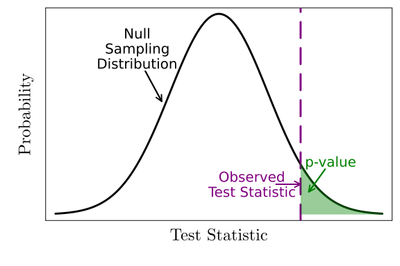

Figure 2: Illustration of a p-value

Two-Tailed Test:

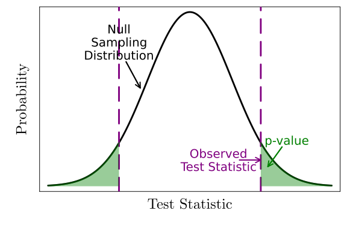

Figure 3: Illustration of a two-tailed p-value

# Statistical Significance

## Error Types

|  |  | **Null Hypothesis Is** |  |
| --- | --- | --- | --- |
|  |  | True | False |
| **Decision About Null Hypothesis** | Don’t reject | True negative (probability $1-\alpha$) | Type II error (probability $\beta$) |
|  | Reject | Type I Error (probability $\alpha$) | True positive (probability $1-\beta$) |

## Navigating Type I and II Errors

The standard null hypothesis significance framework is based on balancing the chance of making **Type I (false positive)** and **Type II (false negative)** errors.

**Idea**: Set a significance level $\alpha$ which is an “acceptable” probability of making a Type I error.

**Aside**: The probability $1-\beta$ of correctly rejecting $H_0$ is the *power*.

# Key Points

## Hypothesis Testing

- Classical framework: Compare a null hypothesis (no effect) to an alternative (some effect)
- $p$-value: probability (under $H_0$) of more extreme test statistic than observed.
- “Significant” if $p$-value is below a significance level reflecting acceptable Type I error rate.

## Problems with NHST framework

- Real “null” hypotheses are often more nuanced than in typical tests (which were often developed for controlled experiments or for computational convenience).
- Decisions are often not binary (“significant/not significant”).
- $p$-values are often over-interpreted and are often be incorrectly calculated, with negative outcomes!
- **Important**: “Big” data can make things worse, as NHST is highly sensitive to small but evidence effects.

# Upcoming Schedule

## Next Classes

**Wednesday**: Introduction to Simulation and Random Sampling

**Friday**: Sampling and Monte Carlo

**Next Week** The Bootstrap

## Assessments

HW4 assigned, due 3/27.

# References